# Warenkorbanalyse: Datenanalyse zum Store Layout Design

2016-08-25

### Setup script

```r
library(tidyverse)
library(arules)
```

```r
library(arulesViz)
library(circlize)
library("treemap")
library("RColorBrewer")

orders <- readRDS('./data/orders.rds')
products <- readRDS('./data/products.rds')
departments <- readRDS('./data/departments.rds')

orders_to_products <- orders %>%
  inner_join(products)
```

# Allgemeine Analysen zum Aufbau des Markets

Namen der Gänge und Abteilungen sind in eigenen Tabellen gespeichert und nur über die Produkte verknüpft. Zur Auswertung kann man diese Tabellen zusammenführen.

Das neue Product Tibble sieht nun so aus:

```r
products
```

| product_id | product_name | is_organic | aisle_id | aisle | department_id | department |
| --- | --- | --- | --- | --- | --- | --- |
| 1 | Chocolate Sandwich Cookies | 0 | 61 | cookies cakes | 19 | snacks |
| 2 | All-Seasons Salt | 0 | 104 | spices seasonings | 13 | pantry |
| 3 | Robust Golden Unsweetened Oolong Tea | 0 | 94 | tea | 7 | beverages |
| 4 | Smart Ones Classic Favorites Mini Rigatoni With Vodka Cream Sauce | 0 | 38 | frozen meals | 1 | frozen |
| 5 | Green Chile Anytime Sauce | 0 | 5 | marinades meat preparation | 13 | pantry |
| 6 | Dry Nose Oil | 0 | 11 | cold flu allergy | 11 | personal care |
| 7 | Pure Coconut Water With Orange | 0 | 98 | juice nectars | 7 | beverages |
| 8 | Cut Russet Potatoes Steam N' Mash | 0 | 116 | frozen produce | 1 | frozen |
| 9 | Light Strawberry Blueberry Yogurt | 0 | 120 | yogurt | 16 | dairy eggs |
| 10 | Sparkling Orange Juice & Prickly Pear Beverage | 0 | 115 | water seltzer sparkling water | 7 | beverages |

[output cut: 9990 more lines]

## Verteilung/Hierarchie der Produkte

*Sind alle Produkte einem validen Gang zugeordnet?*

```r
products %>%
  filter(is.na(aisle))
```

| product_id | product_name | is_organic | aisle_id | aisle | department_id | department |
| --- | --- | --- | --- | --- | --- | --- |

*Alle Produkte sind einem einzigen Gang zugeordnet.*

*Sind alle Produkte einer validen Abteilung zugeordnet?*

```r
products %>%
  filter(is.na(department))
```

| product_id | product_name | is_organic | aisle_id | aisle | department_id | department |
| --- | --- | --- | --- | --- | --- | --- |

*Alle Produkte sind einer einzigen Abteilung zugeordnet.*

*Wie viele Gänge haben die Departments*

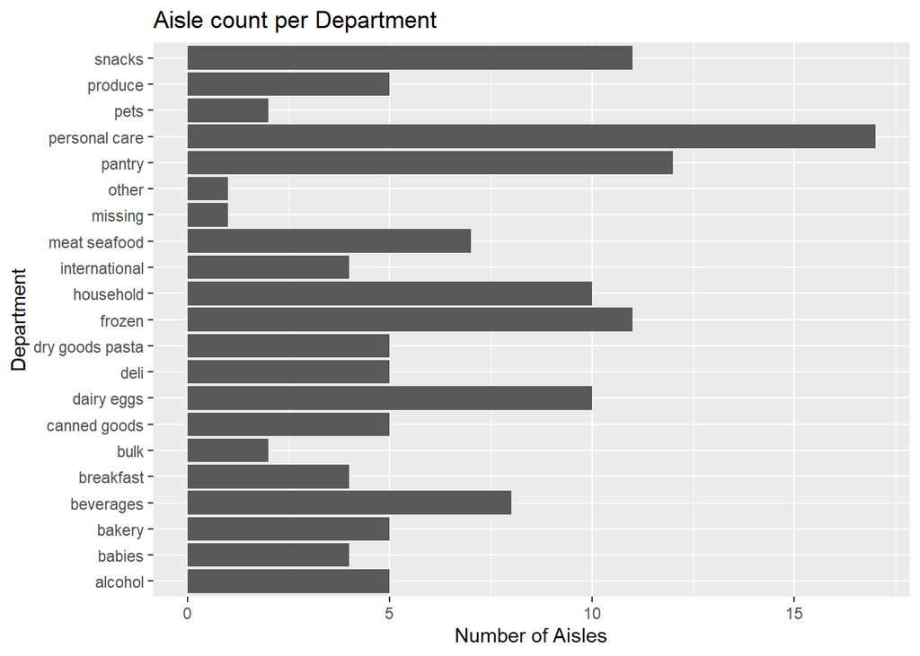

```r
products %>%
  select(aisle, department) %>%
  distinct() %>%
  arrange(department) %>%
  ggplot() +
    geom_bar(aes(x = department)) +
    coord_flip() +
    labs(x="Department", y="Number of Aisles", title="Aisle count per Department")
```

*Wieviele Produkte haben die Abteilungen?*

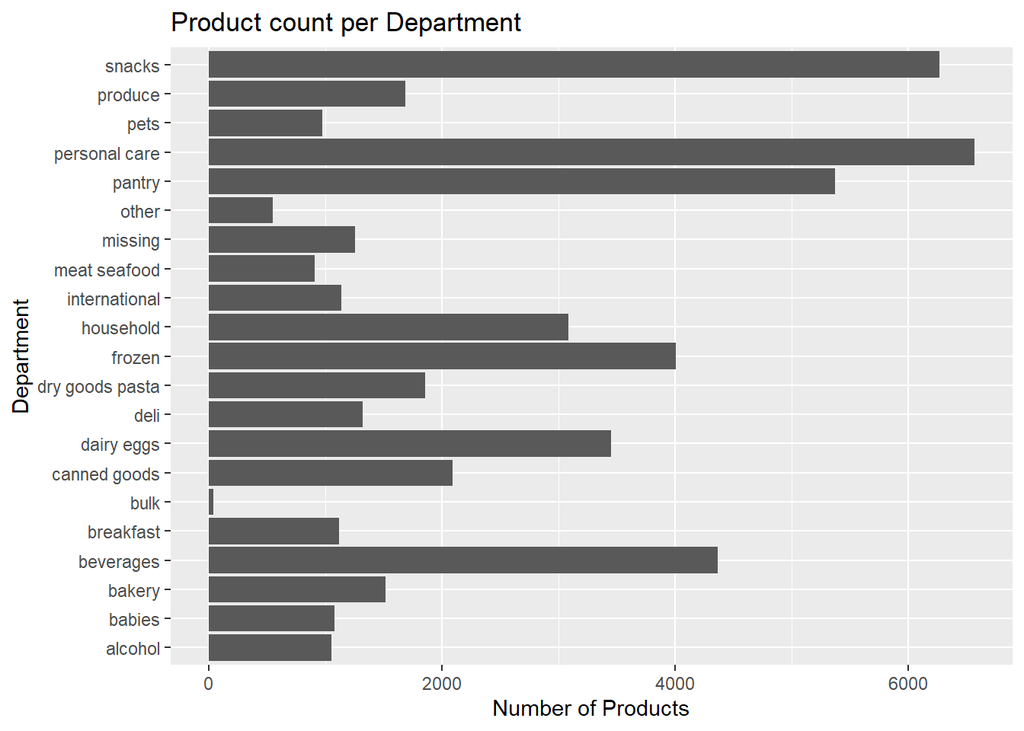

```r
products %>%
  arrange(department) %>%
  ggplot() +
    geom_bar(aes(x = department)) +
    coord_flip() +
    labs(x="Department", y="Number of Products", title="Product count per Department")
```

*Wie kann man die Anzahl Produkte besser Visualisieren in den Abteilungen?*

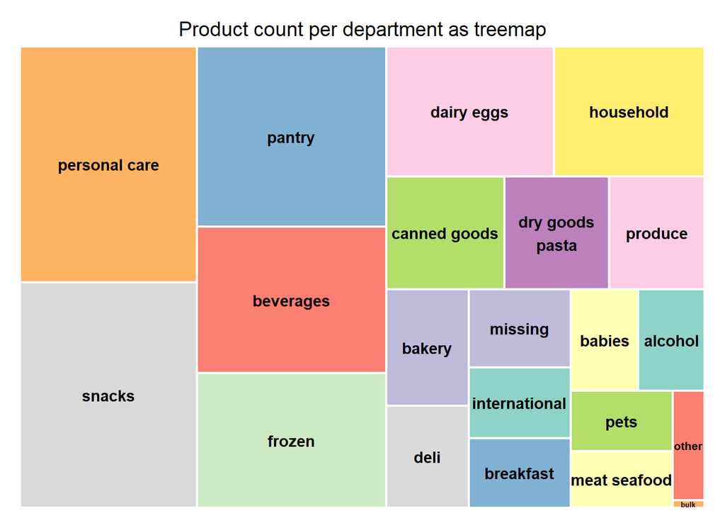

```r
products %>%
  group_by(department) %>%
  mutate(size = 1) %>%
  treemap(index=c("department"),vSize="size",title="Product count per department as treemap",palette="Set3",border.col="#FFFFFF")
```

*Können Gänge mehreren Abteilungen zugewiesen sein?*

```r
products %>%
  select(department, aisle) %>%
  distinct() %>%
  count(aisle, department) %>%
  filter(n > 1)
```

| aisle | department | n |
| --- | --- | --- |

*Gänge sind immer nur einer Abteilung zugewiesen?*

Daraus das jedes Produkt einem spezifischem Gang und jeder Gang einer spezifischen Abteilung zugeordnet ist, lässt sich eine Hierarchie im Store Layout ableiten. Indem man “von oben nach unten” optimiert, kann man von der Allgemeinheit bis ins Detail optimieren. Es bietet sich daher an zuerst auf Ebene Department, dann in den einzelnen Departments auf Ebene Gänge und innerhalb der Gänge auf Ebene Produkte zu optimieren. Allerdings würde das bedeuten, dass die Zuordnung der Produkte in Gänge und der Gänge in Departments schon in Ordnung ist und nicht mehr verändert wird.

# Story Layout Design

## Aktuelles Story Layout Design

Anhand der Reihenfolge, wann etwas in den Warenkorb gelegt wurde, kann man eine wahrscheinliche Version des aktuellen Store Layout Designs herausfinden.

Dazu werden nur Warenkörbe mit mehr als 10 Items beachtet und es wird ein relativer Wert (zwischen 0 und 1) berechnet, welcher angibt, wie früh oder spät aus diesem Department in den Warenkorb gelegt wurde. Je kleiner der Wert im Durchschnitt ist, desto früher muss dieses Department im Story Layout angeordnet sein.

```r
max_add_to_cart_order <- orders_to_products %>%
  group_by(user_id, orders_id) %>%
  summarise(max_add_to_cart_order = max(add_to_cart_order))

# take only those with a minium number of products
department_oder <- max_add_to_cart_order %>%
  filter(max_add_to_cart_order > 10) %>%
  inner_join(orders_to_products) %>%
  mutate(add_to_cart_rel = add_to_cart_order / max_add_to_cart_order) %>%
  group_by(department_id) %>%
  summarise(mean = mean(add_to_cart_rel)) %>%
  arrange(mean) %>%
  inner_join(departments) %>%
  select(department_id, department) %>%
  mutate(sort = row_number())
# add some statistics - number of products
department_oder <- department_oder %>%
  left_join(
    products %>%
      group_by(department_id) %>%
      summarise(product_count = n())
  ) %>%
  left_join(
    products %>%
      select(department_id, aisle_id) %>%
      distinct() %>%
      group_by(department_id) %>%
      summarise(aisle_count = n())
  ) %>%
  mutate(avg_product_per_aisle = product_count /aisle_count)
max_add_to_cart_order
```

| user_id | orders_id | max_add_to_cart_order |
| --- | --- | --- |
| 1 | 431534 | 8 |
| 1 | 473747 | 5 |
| 1 | 550135 | 5 |
| 1 | 1187899 | 11 |
| 1 | 2254736 | 5 |
| 1 | 2295261 | 6 |
| 1 | 2398795 | 6 |
| 1 | 2539329 | 5 |
| 1 | 2550362 | 9 |
| 1 | 3108588 | 6 |

[output cut: 9990 more lines]

```r
department_oder
```

| department_id | department | sort | product_count | aisle_count | avg_product_per_aisle |
| --- | --- | --- | --- | --- | --- |
| 16 | dairy eggs | 1 | 3449 | 10 | 344.9000 |
| 7 | beverages | 2 | 4365 | 8 | 545.6250 |
| 8 | pets | 3 | 972 | 2 | 486.0000 |
| 3 | bakery | 4 | 1516 | 5 | 303.2000 |
| 4 | produce | 5 | 1684 | 5 | 336.8000 |
| 5 | alcohol | 6 | 1054 | 5 | 210.8000 |
| 20 | deli | 7 | 1322 | 5 | 264.4000 |
| 12 | meat seafood | 8 | 907 | 7 | 129.5714 |
| 18 | babies | 9 | 1081 | 4 | 270.2500 |
| 1 | frozen | 10 | 4007 | 11 | 364.2727 |

[output cut: 11 more lines]

Dies ist die Liste, in welcher Reihenfolge im Durchschnitt gekauft wird. Dies ist natürlich eine Annäherung und die Realität kann davon abweichen. Es gibt aber zumindest einen ersten Einblick, wie das aktuelle Store Layout Design sein könnte. Aus der Reihenfolge lässt sich allerdings nur ein “Pfad” ableiten. Die meisten Supermärkte sind allerdings nicht ähnlich wie ein IKEA aufgebaut, bei der es einen Hauptweg durch den ganzen Markt gibt.

## Analyse von häufig zusammen gekaufter Elemente

Mithilfe einer Assoziationsanalyse lässt sich herausfinden welche Produkte häufig zusammen gekauft werden. Aufgrund der herausgefundenen Hierarchie und der grossen Anzahl Produkte scheint es unwahrscheinlich, dass auf Ebene der Produkte viel brauchbares herauskommt.

### Häufig zusammen gekaufte Produkte

Wir benutzen dafür den Apriori Alghorithmus. Dieser sieht vor, dass man zuerst alle Warenkörbe als Set zusammenfasst.

```r
baskets <- orders_to_products %>%
  group_by(orders_id) %>%
  summarise(items = as.vector(list(product_name)))

transactions <- as(baskets$items, "transactions")
```

Mit dem Arules Package für R kann man sich nun den Support ausrechnen und auch plotten lassen. Dieser gibt an, mit welcher Wahrscheinlichkeit ein Produkt in einem Warenkorb landet. Die 30 Produkte mit dem höchsten Support sehen folgendermassen aus:

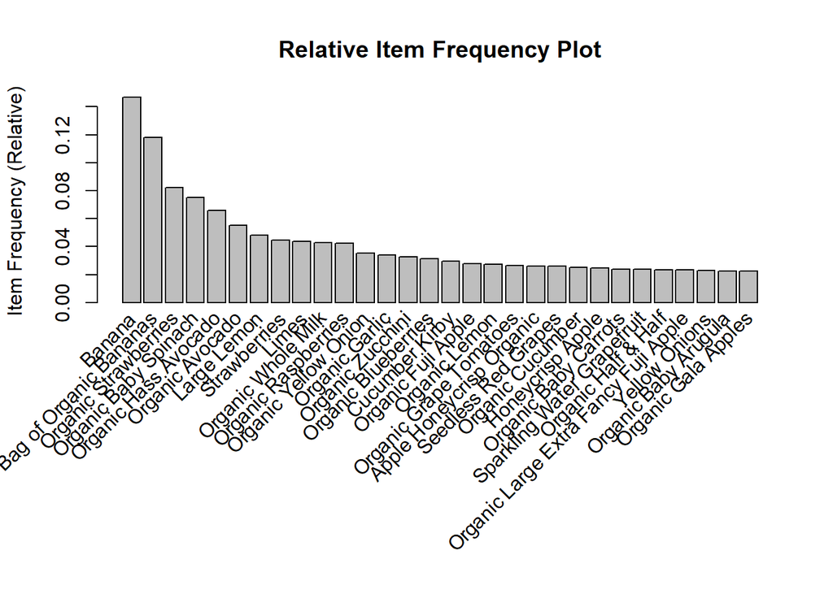

```r
arules::itemFrequencyPlot(transactions,
   topN=30,
   main='Relative Item Frequency Plot',
   type="relative",
   ylab="Item Frequency (Relative)")
```

```r
item_frequency <- tibble::enframe(itemFrequency(transactions, type="relative")) %>%
  rename(support = value, product_name = name)
```

In Form einer Tabelle sieht das so aus:

```r
item_frequency %>%
  arrange(desc(support)) %>%
  top_n(30)
```

| product_name | support |
| --- | --- |
| Banana | 0.14682571 |
| Bag of Organic Bananas | 0.11802756 |
| Organic Strawberries | 0.08235809 |
| Organic Baby Spinach | 0.07522378 |
| Organic Hass Avocado | 0.06601062 |
| Organic Avocado | 0.05505661 |
| Large Lemon | 0.04805380 |
| Strawberries | 0.04466267 |
| Limes | 0.04383035 |
| Organic Whole Milk | 0.04268065 |

[output cut: 20 more lines]

Die 6 am häufigsten auftretenden Produkte haben eine relative Häufigket von über 5%. Auf Platz 30 sind es schon nur noch knapp über 2%.

Die Ausreisser sind hier “Banana” mit ~14,7% und “Bag of organic Bananas” mit ~11,8%.

Die allgemeine Verteilung des Supports ist folgendermassen:

```r
summary(item_frequency)
```

```
##  product_name          support
##  Length:49685       Min.   :3.000e-07
##  Class :character   1st Qu.:5.380e-06
##  Mode  :character   Median :1.883e-05
##                     Mean   :2.034e-04
##                     3rd Qu.:8.129e-05
##                     Max.   :1.468e-01
```

Im Median tritt in ein Produkt nur in 0.0019% der Fälle im Warenkorb auf. Im Durchschnitt sind es 0.02%. Bei 49685 Produkten kann man also sagen, dass die Warenkörbe bis auf einige wenige Ausnahmen ziemlich divers sind. Eine Assoziationsanalyse lohnt sich hier als wahrscheinlich nur bedingt.

```r
quantile(item_frequency$support, c(.9, .95, .98))
```

```
##          90%          95%          98%
## 0.0003185815 0.0007120565 0.0017009859
```

Selbst die 2% der Produkte mit der höchsten Verteilung haben eine minimale relative Häufigkeit von 0.17%. Es muss daher für die Assoziationsanalysie ein niedriger Wert für den Support angenommen werden.

```r
apriori_formatted <- function(transactions, support, confidence, minlen = 2) {
  rules <- apriori(transactions, parameter = list(supp = support, conf = confidence, target="rules", minlen=minlen))
  rules <- rules[!is.redundant(rules)]
  rules_tib <- tibble( lhs = labels( lhs(rules) ),
          rhs = labels( rhs(rules) ),
          support = (quality(rules) %>% pull(support)),
          confidence = (quality(rules) %>% pull(confidence)),
          lift = (quality(rules) %>% pull(lift)),
          count = (quality(rules) %>% pull(count)))
  rules_tib
}
```

```r
products_assoc <- apriori_formatted(transactions, 0.0003, 0.05)
```

```
## Apriori
##
## Parameter specification:
##  confidence minval smax arem  aval originalSupport maxtime support minlen
##        0.05    0.1    1 none FALSE            TRUE       5   3e-04      2
##  maxlen target   ext
##      10  rules FALSE
##
## Algorithmic control:
##  filter tree heap memopt load sort verbose
##     0.1 TRUE TRUE  FALSE TRUE    2    TRUE
##
## Absolute minimum support count: 1003
##
## set item appearances ...[0 item(s)] done [0.00s].
## set transactions ...[49685 item(s), 3346083 transaction(s)] done [22.07s].
## sorting and recoding items ... [5224 item(s)] done [0.55s].
## creating transaction tree ... done [4.17s].
## checking subsets of size 1 2 3 4 5
```

```
##  done [6.34s].
## writing ... [22347 rule(s)] done [0.05s].
## creating S4 object  ... done [0.74s].
```

```r
products_assoc %>%
  arrange(-count)
```

| lhs | rhs | support | confidence | lift | count |
| --- | --- | --- | --- | --- | --- |
| {Organic Hass Avocado} | {Bag of Organic Bananas} | 0.0193542718 | 0.29319938 | 2.4841604 | 64761 |
| {Bag of Organic Bananas} | {Organic Hass Avocado} | 0.0193542718 | 0.16398096 | 2.4841604 | 64761 |
| {Organic Strawberries} | {Bag of Organic Bananas} | 0.0193366393 | 0.23478737 | 1.9892590 | 64702 |
| {Bag of Organic Bananas} | {Organic Strawberries} | 0.0193366393 | 0.16383157 | 1.9892590 | 64702 |
| {Organic Strawberries} | {Banana} | 0.0174323231 | 0.21166498 | 1.4416071 | 58330 |
| {Banana} | {Organic Strawberries} | 0.0174323231 | 0.11872800 | 1.4416071 | 58330 |
| {Organic Avocado} | {Banana} | 0.0166197312 | 0.30186621 | 2.0559493 | 55611 |
| {Banana} | {Organic Avocado} | 0.0166197312 | 0.11319361 | 2.0559493 | 55611 |
| {Organic Baby Spinach} | {Banana} | 0.0159574643 | 0.21213325 | 1.4447964 | 53395 |
| {Banana} | {Organic Baby Spinach} | 0.0159574643 | 0.10868304 | 1.4447964 | 53395 |

[output cut: 9990 more lines]

```r
#Conviction
#tried adding conviction, not possible to add into function because of dataframe strucuture, not found alternatives. Mario your call to keep or discard.
rules_outed <- apriori(transactions, parameter = list(supp = 0.0003, conf = 0.05, target="rules", minlen=2))
```

```
## Apriori
##
## Parameter specification:
##  confidence minval smax arem  aval originalSupport maxtime support minlen
##        0.05    0.1    1 none FALSE            TRUE       5   3e-04      2
##  maxlen target   ext
##      10  rules FALSE
##
## Algorithmic control:
##  filter tree heap memopt load sort verbose
##     0.1 TRUE TRUE  FALSE TRUE    2    TRUE
##
## Absolute minimum support count: 1003
##
## set item appearances ...[0 item(s)] done [0.00s].
## set transactions ...[49685 item(s), 3346083 transaction(s)] done [21.85s].
## sorting and recoding items ... [5224 item(s)] done [0.55s].
## creating transaction tree ... done [4.26s].
## checking subsets of size 1 2 3 4 5
```

```
##  done [6.35s].
## writing ... [22347 rule(s)] done [0.05s].
## creating S4 object  ... done [0.73s].
```

```r
rules_outed_wconv <- cbind(as(rules_outed, "data.frame"), conviction = interestMeasure(rules_outed, "conviction", transactions))
```

Anhand der Liste sieht man wie oft die häufigsten Kombinationen auftreten. Es ist recht schwierig anhand dessen ein Storlayout vorzuschlagen. Mit den Informationen ist es erstmal nicht zielführend.

### Häufig aus bestimmten Abteilungen gekauft

Man kann die gleiche Assoziationsanalyse auch auf Ebene der Abteilungen machen.

```r
baskets_department <- orders_to_products %>%
  select(orders_id, department) %>%
  distinct() %>%
  group_by(orders_id) %>%
  summarise(items = as.vector(list(department)))

transactions_department <- as(baskets_department$items, "transactions")
```

Der Item Frequency Plot sieht in dem Fall so aus:

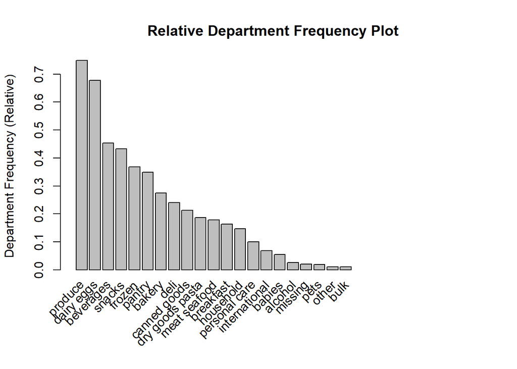

```r
arules::itemFrequencyPlot(transactions_department,
   topN=30,
   main='Relative Department Frequency Plot',
   type="relative",
   ylab="Department Frequency (Relative)")
```

Und die zugehörige Tabelle:

```r
department_frequency <- tibble::enframe(itemFrequency(transactions_department, type="relative")) %>%
  rename(support = value, department = name)
```

```r
department_frequency %>%
  mutate(support = round(support, 2)) %>%
  arrange(desc(support))
```

| department | support |
| --- | --- |
| produce | 0.75 |
| dairy eggs | 0.68 |
| beverages | 0.45 |
| snacks | 0.43 |
| frozen | 0.37 |
| pantry | 0.35 |
| bakery | 0.27 |
| deli | 0.24 |
| canned goods | 0.21 |
| dry goods pasta | 0.19 |

[output cut: 11 more lines]

Hier sieht man, dass ca. 75% aller Einkäufe Waren aus “produce” und 67,7% aller Einkäufe Waren aus “dairy eggs” beinhalten. Diese sind mit einem Abstand von mehr als 20% vor der nächsten Abteilung “beverages”.

Man kann also schon sagen, dass sich das Storelayout auf “produce” und “dairy eggs” als zentrale Elemente konzentrieren sollte.

```r
departments_assoc <- apriori_formatted(transactions_department, 0.01, 0.01, minlen=1) %>% as.tibble()
```

```
## Apriori
##
## Parameter specification:
##  confidence minval smax arem  aval originalSupport maxtime support minlen
##        0.01    0.1    1 none FALSE            TRUE       5    0.01      1
##  maxlen target   ext
##      10  rules FALSE
##
## Algorithmic control:
##  filter tree heap memopt load sort verbose
##     0.1 TRUE TRUE  FALSE TRUE    2    TRUE
##
## Absolute minimum support count: 33460
##
## set item appearances ...[0 item(s)] done [0.00s].
## set transactions ...[21 item(s), 3346083 transaction(s)] done [1.09s].
## sorting and recoding items ... [21 item(s)] done [0.19s].
## creating transaction tree ... done [3.48s].
## checking subsets of size 1 2 3 4 5 6 7 8 done [0.32s].
## writing ... [13536 rule(s)] done [0.00s].
## creating S4 object  ... done [0.52s].
```

```r
departments_assoc %>%
  arrange(-count) %>%
  filter(str_count(lhs,',')==0) %>%
  mutate(support = round(support, 2)) %>%
  mutate(confidence = round(confidence, 2)) %>%
  mutate(lift = round(lift, 2)) -> tidied_dep_assoc

tidied_dep_assoc
```

| lhs | rhs | support | confidence | lift | count |
| --- | --- | --- | --- | --- | --- |
| {} | {produce} | 0.75 | 0.75 | 1.00 | 2506247 |
| {} | {dairy eggs} | 0.68 | 0.68 | 1.00 | 2264738 |
| {dairy eggs} | {produce} | 0.55 | 0.81 | 1.09 | 1841091 |
| {produce} | {dairy eggs} | 0.55 | 0.73 | 1.09 | 1841091 |
| {} | {beverages} | 0.45 | 0.45 | 1.00 | 1518833 |
| {} | {snacks} | 0.43 | 0.43 | 1.00 | 1448749 |
| {} | {frozen} | 0.37 | 0.37 | 1.00 | 1232089 |
| {} | {pantry} | 0.35 | 0.35 | 1.00 | 1165491 |
| {snacks} | {produce} | 0.34 | 0.78 | 1.04 | 1128643 |
| {produce} | {snacks} | 0.34 | 0.45 | 1.04 | 1128643 |

[output cut: 255 more lines]

```r
#Tried chord diagramm, not clear nor tidy
#tidied_dep_assoc %>%
#  filter(count > 1115000) %>%
#  chordDiagram(transparency = 0.3)
```

# Zusammenfassung

- Die wichtigsten Abteilungen sind “produce” und “dairy eggs” was die Anzahl verkäufe angeht.
- Die Departments die einen hohen support miteinander haben sollen wenn möglich nebeneinander liegen
- Der zusammenhange zwischen Departments muss beachtet sein, dies bedeutet wenn der Kunde im department “A” (LHS) etwas einkauft, ist es so und so wahrscheinlich (confidence) das er im department “B” (RHS) auch etwas kauft.

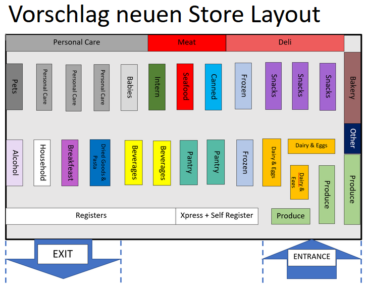

StoreLayoutFinal